# Cox Proportional Hazard Models

# Cox Proportional Hazard Survival Models

Using the same dataset from the Kaplan-Meier analysis.

```r
url <- "http://socserv.mcmaster.ca/jfox/Books/Companion/data/Rossi.txt"
rossi <- read.table(url, header=TRUE)
```

Fit an initial CPH model with all the variables available (except the time-dependent one). Coefficients with a negative value mean that the chances of being arrested are lower (higher survival chances). Coefficients with positive coefficients (exp(coefficients) > 1) imply higher chances of being arrested (lower survival chances).

```r
cph_full <- coxph(Surv(week, arrest) ~ fin + age + race + wexp + mar + paro + prio,
                     data = rossi)

summary(cph_full)
```

```
## Call:
## coxph(formula = Surv(week, arrest) ~ fin + age + race + wexp +
##     mar + paro + prio, data = rossi)
##
##   n= 432, number of events= 114
##
##                    coef exp(coef) se(coef)      z Pr(>|z|)
## finyes         -0.37942   0.68426  0.19138 -1.983  0.04742 *
## age            -0.05744   0.94418  0.02200 -2.611  0.00903 **
## raceother      -0.31390   0.73059  0.30799 -1.019  0.30812
## wexpyes        -0.14980   0.86088  0.21222 -0.706  0.48029
## marnot married  0.43370   1.54296  0.38187  1.136  0.25606
## paroyes        -0.08487   0.91863  0.19576 -0.434  0.66461
## prio            0.09150   1.09581  0.02865  3.194  0.00140 **
## ---
## Signif. codes:  0 '***' 0.001 '**' 0.01 '*' 0.05 '.' 0.1 ' ' 1
##
##                exp(coef) exp(-coef) lower .95 upper .95
## finyes            0.6843     1.4614    0.4702    0.9957
## age               0.9442     1.0591    0.9043    0.9858
## raceother         0.7306     1.3688    0.3995    1.3361
## wexpyes           0.8609     1.1616    0.5679    1.3049
## marnot married    1.5430     0.6481    0.7300    3.2614
## paroyes           0.9186     1.0886    0.6259    1.3482
## prio              1.0958     0.9126    1.0360    1.1591
##
## Concordance= 0.64  (se = 0.027 )
## Likelihood ratio test= 33.27  on 7 df,   p=2e-05
## Wald test            = 32.11  on 7 df,   p=4e-05
## Score (logrank) test = 33.53  on 7 df,   p=2e-05
```

Plot the survival curve from this model fit.

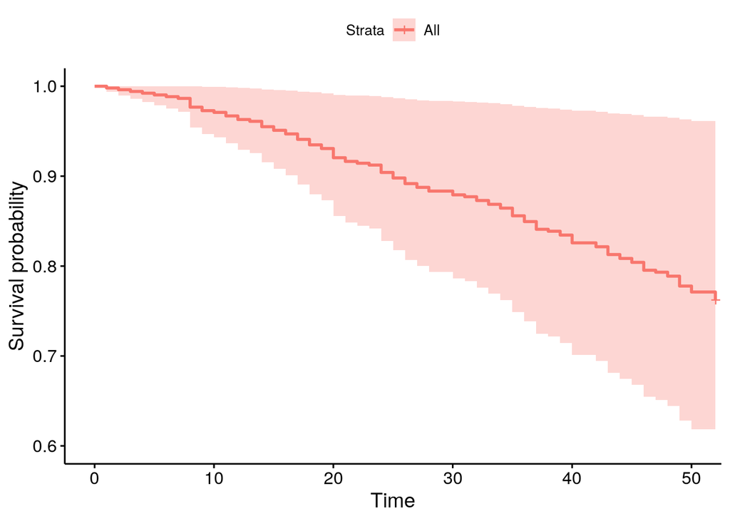

```r
ggsurvplot(survfit(cph_full), data = rossi, ylim = c(0.6, 1))
```

Show the specific predictions from the model for a couple different rows in the data.

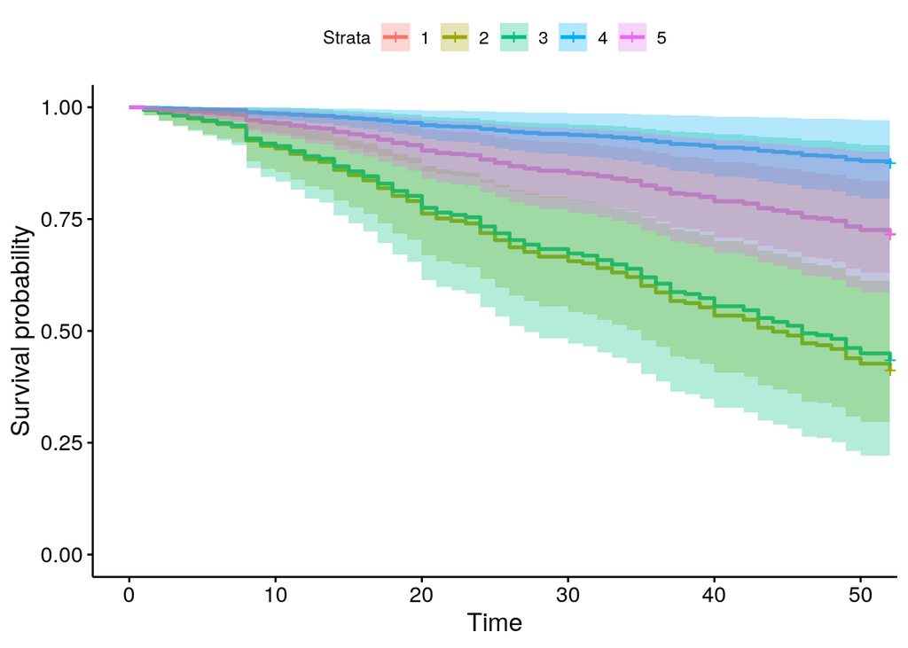

```r
#rossi[1:5,3:10]
ggsurvplot(survfit(cph_full, newdata = rossi[1:5,]), data = rossi)
```

Since the cox model is proportional, the estimated hazard rates over time for different individuals in the data are estimated to be some multiplicative factor of the base hazard. The code below shows that when we divide the cumulative hazard for row 1 by the cumulative hazard for row 2 we get a constant value for all time periods.

So we can say something to the effect of: “The combination of variables for individual A make their hazard rate X times the hazard rate of individual B” where X is some scalar value. Without more complicated model features, the hazard rates will be proportional.

```r
preds <- survfit(cph_full, newdata = rossi[1:5,])
preds$cumhaz[,1] / preds$cumhaz[,2]
```

```
##  [1] 0.3774093 0.3774093 0.3774093 0.3774093 0.3774093 0.3774093 0.3774093
##  [8] 0.3774093 0.3774093 0.3774093 0.3774093 0.3774093 0.3774093 0.3774093
## [15] 0.3774093 0.3774093 0.3774093 0.3774093 0.3774093 0.3774093 0.3774093
## [22] 0.3774093 0.3774093 0.3774093 0.3774093 0.3774093 0.3774093 0.3774093
## [29] 0.3774093 0.3774093 0.3774093 0.3774093 0.3774093 0.3774093 0.3774093
## [36] 0.3774093 0.3774093 0.3774093 0.3774093 0.3774093 0.3774093 0.3774093
## [43] 0.3774093 0.3774093 0.3774093 0.3774093 0.3774093 0.3774093 0.3774093
```

The cox proportional hazard model is a combination of a non-parametric ‘baseline hazard’ along with a parametric portion which is the ’proportional hazards given by exp(beta*X). The relative differences between the proportional pieces of the hazard are given by the betas in the fit. To get the baseline hazard, that can be pulled from the model using `basehaz()`. This can be thought of as the ‘q’ in a mortality model before it is modified by the coefficients for each individual. The survival curve can be derived from these values by stepping forward each time period and applying this hazard rate to get the probability of surviving to the next time period.

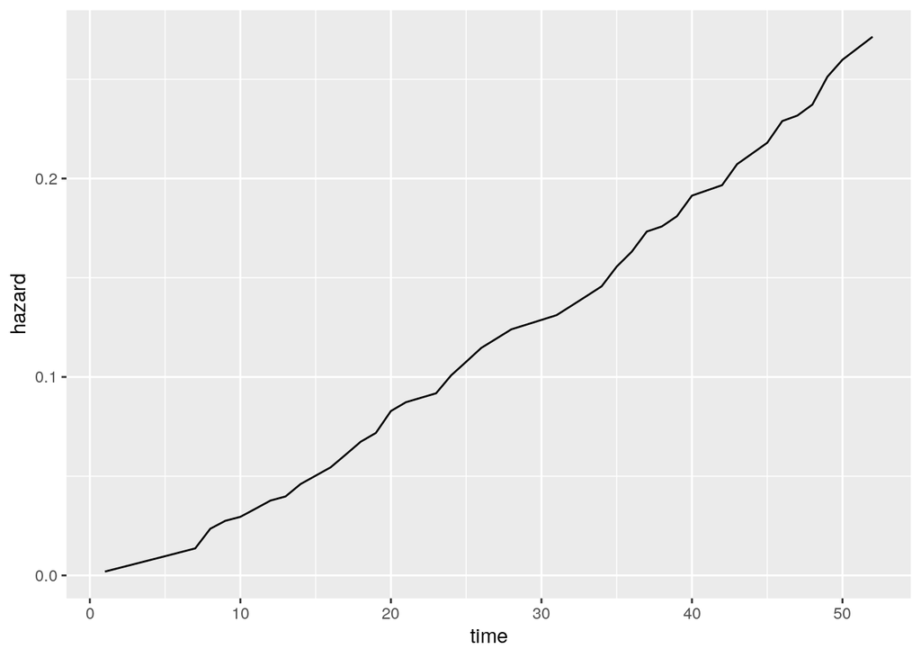

```r
#basehaz(cph_full)
ggplot(basehaz(cph_full)) + geom_line(aes(x = time, y = hazard))
```

There is one ‘baseline hazard’ rate fit for ALL observations. This can be changed by using `strata()` in the formula when fitting the model. This fits different baseline hazards for each strata in the group varaible. For example, if we wanted to fit a different baseline hazard for married vs non-married individuals in the data, we would use the following code.

One question I still have: Are the coefficients the same between strata? It would seem so given that the summary doens’t show different coefficients by strata, but I’m not 100% sure. To fit different coefficients, it’s probably easier to just split the data in two and fit two models with different baseline hazards and coefficients. This seems to imply that splitting the model by strata assumes that the factors affect different strata exactly the same way. For example, the number of prior arrests has the same impact on survival regardless of whether or not the individual was married.

```r
cph_full2 <- coxph(Surv(week, arrest) ~ fin + age + race + wexp + strata(mar) + paro + prio,
                     data = rossi)

summary(cph_full2)
```

```
## Call:
## coxph(formula = Surv(week, arrest) ~ fin + age + race + wexp +
##     strata(mar) + paro + prio, data = rossi)
##
##   n= 432, number of events= 114
##
##               coef exp(coef) se(coef)      z Pr(>|z|)
## finyes    -0.37677   0.68607  0.19137 -1.969  0.04898 *
## age       -0.05728   0.94433  0.02198 -2.606  0.00916 **
## raceother -0.31543   0.72948  0.30809 -1.024  0.30591
## wexpyes   -0.14967   0.86099  0.21221 -0.705  0.48062
## paroyes   -0.08627   0.91734  0.19575 -0.441  0.65940
## prio       0.09074   1.09499  0.02862  3.171  0.00152 **
## ---
## Signif. codes:  0 '***' 0.001 '**' 0.01 '*' 0.05 '.' 0.1 ' ' 1
##
##           exp(coef) exp(-coef) lower .95 upper .95
## finyes       0.6861     1.4576    0.4715    0.9983
## age          0.9443     1.0590    0.9045    0.9859
## raceother    0.7295     1.3708    0.3988    1.3343
## wexpyes      0.8610     1.1615    0.5680    1.3051
## paroyes      0.9173     1.0901    0.6250    1.3463
## prio         1.0950     0.9133    1.0353    1.1582
##
## Concordance= 0.623  (se = 0.028 )
## Likelihood ratio test= 28.4  on 6 df,   p=8e-05
## Wald test            = 27.83  on 6 df,   p=1e-04
## Score (logrank) test = 28.9  on 6 df,   p=6e-05
```

Now that we fit a model with two strata, we can show the different baseline hazards for the two strata: married and non-married individuals:

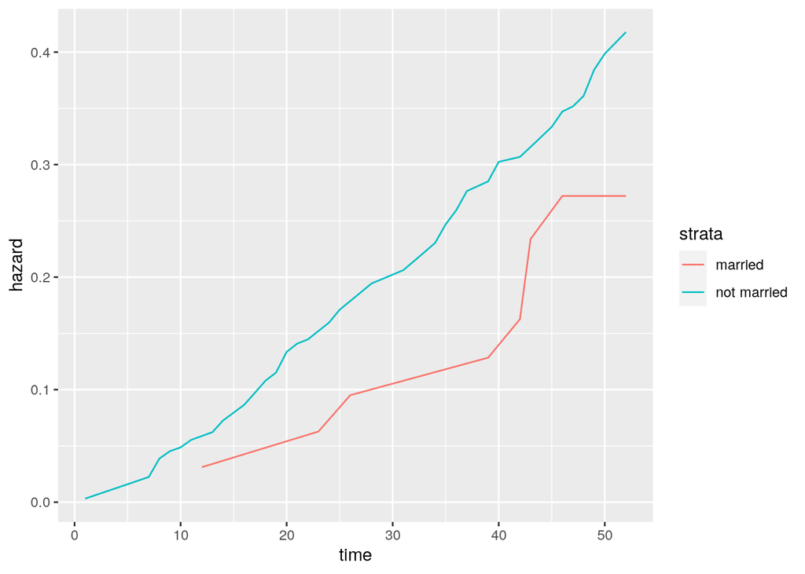

```r
basehaz(cph_full2) %>%
  ggplot() + geom_line(aes(x = time, y = hazard, color = strata))
```

We can plot the Kaplan-Meier survival curve against the base hazard from the CPH model. The survival curve produced from `survfit.cph()` here uses the mean of each input variable to produce this curve, which may not be a reasonable output for the CPH model.

Technical note here: for some reason `ggsurvplot(..., combine = TRUE)` produces an error, but when I use the underlying function `ggsurvplot_combine()` it works OK. Wish it was less buggy, this is a super nice feature, really beats having to extract survival curves manually, combine, and ggplot.

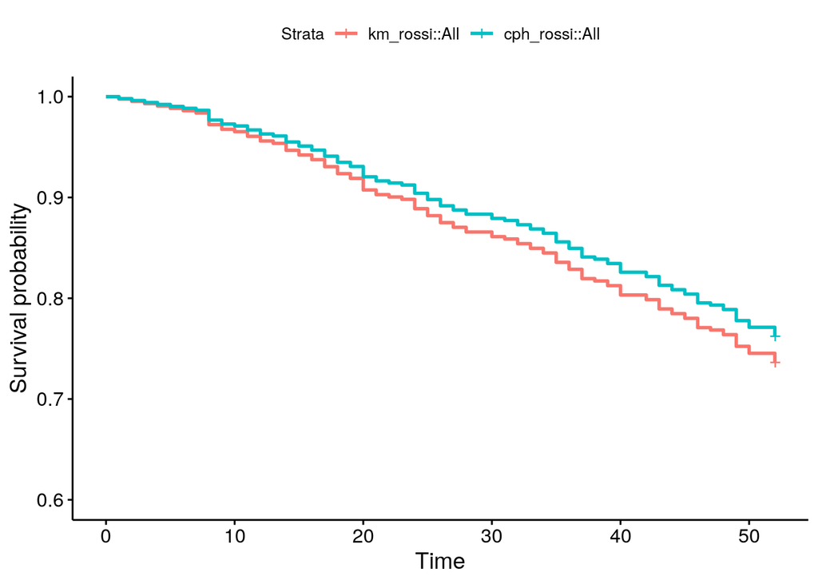

```r
km_rossi <- survfit(Surv(week, arrest) ~ 1, data = rossi)
cph_rossi <- survfit(cph_full)

ggsurvplot_combine(list(km_rossi, cph_rossi),
           data = rossi,
           combine = TRUE,
           ylim = c(0.6, 1))
```

How can we improve the fit of this model, and what are the metrics used to compare models with different sets of variables and different features?

Test out using log of the prior arrests to see if it improves performance. Concordance goes up which is an indicator of better fit. All the other tests go down, which I think is the right direction, but need to do more research on that.

```r
cph_full3 <- coxph(Surv(week, arrest) ~ fin + age + race + wexp + mar + paro + log(prio + 1),
                     data = rossi)

summary(cph_full3)
```

```
## Call:
## coxph(formula = Surv(week, arrest) ~ fin + age + race + wexp +
##     mar + paro + log(prio + 1), data = rossi)
##
##   n= 432, number of events= 114
##
##                    coef exp(coef) se(coef)      z Pr(>|z|)
## finyes         -0.36966   0.69097  0.19130 -1.932  0.05331 .
## age            -0.05669   0.94489  0.02199 -2.578  0.00995 **
## raceother      -0.33666   0.71415  0.30837 -1.092  0.27496
## wexpyes        -0.17483   0.83960  0.21050 -0.831  0.40621
## marnot married  0.41230   1.51028  0.38156  1.081  0.27989
## paroyes        -0.11178   0.89424  0.19492 -0.573  0.56632
## log(prio + 1)   0.41282   1.51107  0.15533  2.658  0.00787 **
## ---
## Signif. codes:  0 '***' 0.001 '**' 0.01 '*' 0.05 '.' 0.1 ' ' 1
##
##                exp(coef) exp(-coef) lower .95 upper .95
## finyes            0.6910     1.4472    0.4749    1.0053
## age               0.9449     1.0583    0.9050    0.9865
## raceother         0.7142     1.4003    0.3902    1.3070
## wexpyes           0.8396     1.1910    0.5558    1.2684
## marnot married    1.5103     0.6621    0.7150    3.1904
## paroyes           0.8942     1.1183    0.6103    1.3103
## log(prio + 1)     1.5111     0.6618    1.1145    2.0488
##
## Concordance= 0.643  (se = 0.027 )
## Likelihood ratio test= 31.36  on 7 df,   p=5e-05
## Wald test            = 28.85  on 7 df,   p=2e-04
## Score (logrank) test = 29.68  on 7 df,   p=1e-04
```

```r
paste0("AIC on original model: ", extractAIC(cph_full)[2], "\n", "AIC on modified model: ", extractAIC(cph_full2)[2]) %>%
  writeLines
```

```
## AIC on original model: 1331.49531889217
## AIC on modified model: 1272.22040115392
```

Compare km fit on one dimension to cph fit on one dimension

Play around with aalens additive regression model? make another file to do this: aareg.Rmd